# act_report

## DOGS ARE JUST SO CUTE.

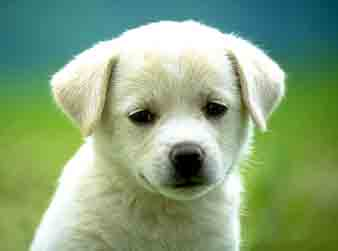

### Column Description

`tweet_id`: contains the unique id for each tweet in the dataset

`timestamp`: contains the timestamp for each tweet i.ethe exact time each tweet was put out

`source`: the device or platform from were these tweets originated from

`tesxt`: contains the words and sentences that were put out in the tweet

`rating_numerator`: contains the numerator score for each dog picture that was put out

`name`: contains the name for each dogs whose photos were tweeted

`dog_stage`: shows the stage the dogs are in. it can be a 'floofer', 'puppo', 'pupper', and doggo', or a double combination of any of the satages like 'floofer puppo'

`text_range`: this the length of the text in the text column

`favorite_count`: contains the amount of times each tweet was favorited

`favorited`: a boolean column that shows True if the tweet was favorited by weratedogs, and False if it was not favorited

`lang`: shows the language acronym each tweet was put out in

`retweet_count`: shows the number of times each tweet was retweeted

`jpg_url`: shows the link to the dog photos in each tweet

`img_num`: contains the number of photos for the dogs that was put out. it is either 1,2,3 or 4.

`p1`: this is the result of a machine learning algorithm that predicts the breed of dog based of the image that it was fed. this p1 column contains the 1st predicted breed name

`p1_conf`: THis shows the confidence level of the algorithm on the predicted breed on a scale of 0-1.

`p1_dog`: Contains a boolean for the p1_conf.

`p2`: this is the result of a machine learning algorithm that predicts the breed of dog based of the image that it was fed. this p2 column contains the 2nd predicted breed name

`p2_conf`: THis shows the confidence level of the algorithm on the predicted breed on a scale of 0-1.

`p2_dog`: Contains a boolean for the p2_conf.

`p3`: this is the result of a machine learning algorithm that predicts the breed of dog based of the image that it was fed. this p3 column contains the 3rd predicted breed name

`p3_conf`: THis shows the confidence level of the algorithm on the predicted breed on a scale of 0-1.

`p3_dog`: Contains a boolean for the p3_conf.

### Insights

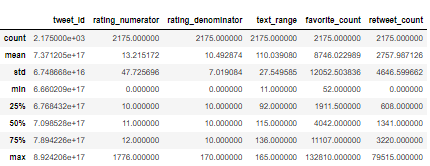

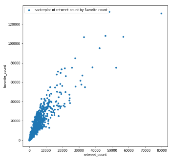

- There is a strong positive corelation between the retweet_count and the favorite_count

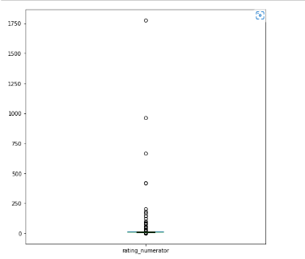

- There are numerous outliers in the rating_numerator columns

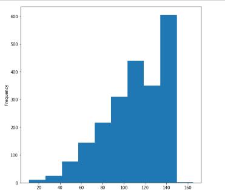

- The text_range values are negatively skewed (this may be because of some outliers present in it)

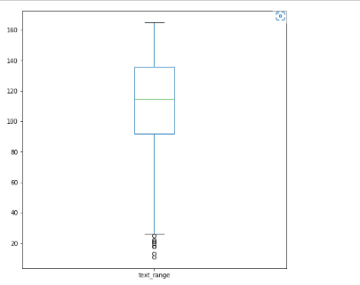

### Visualizations

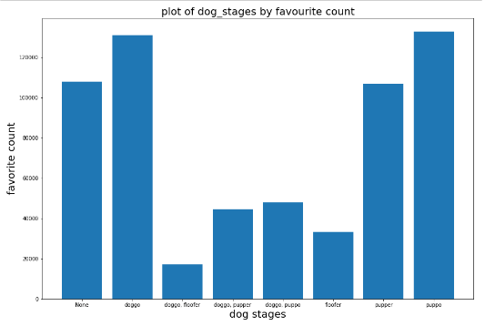

- From our visualization above, we can see that both 'puppo' and 'doggo' dog stages had the highest favorite count and both 'doggo floofer' and 'floofer' both had the least favorite count

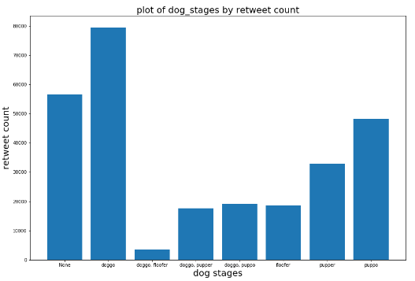